# Assignment_2_template

### Add libraries

```python
import os
os.environ['TF_CPP_MIN_LOG_LEVEL'] = '3' #  Turn off some unimportant messages
```

```python
import tensorflow as tf
from keras.applications.vgg19 import VGG19
from keras.applications.resnet import ResNet50
from tensorflow.keras.models import Model
from tensorflow.keras.layers import Flatten, Dense, Dropout
import numpy as np
from sklearn.preprocessing import OneHotEncoder
from sklearn.model_selection import train_test_split
from sklearn.metrics import confusion_matrix
import pandas as pd
import matplotlib.pyplot as plt
from tensorflow.keras.regularizers import l1_l2
from tensorflow.keras.optimizers import Adam
import seaborn as sns
```

```
WARNING: All log messages before absl::InitializeLog() is called are written to STDERR
E0000 00:00:1739952653.869597    1035 cuda_dnn.cc:8310] Unable to register cuDNN factory: Attempting to register factory for plugin cuDNN when one has already been registered
E0000 00:00:1739952653.892811    1035 cuda_blas.cc:1418] Unable to register cuBLAS factory: Attempting to register factory for plugin cuBLAS when one has already been registered
```

### Path system

```python
# you need the current working directory NB: works both windows and linux
current_working_directory = os.getcwd()
current_working_directory = os.path.dirname(current_working_directory)

# get the directory where I want to download the dataset
path_of_download = os.path.join(*['..', current_working_directory,'Assignment2','weather_dataset'])
print(f"[DIR] The directory of the current dataset is {path_of_download}")
```

```
[DIR] The directory of the current dataset is /mnt/c/UTU/2025/Computer Vision and Sensor Fusion/Assignment2/weather_dataset
```

### function for data loading

```python
# here let s do some functions that we can re-use also for other assignment
def load_the_data_and_the_labels(data_set_path: str, target_size: tuple or None = None):
    try:
        dataset, labels, name_of_the_labels = list(), list(), list()
        # let s loop here and we try to discover how many class we have
        for class_number, class_name in enumerate(os.listdir(data_set_path)):
            full_path_the_data = os.path.join(data_set_path, class_name)
            print(f"[WALK] I am walking into {full_path_the_data}")

            # add the list to nam _list
            name_of_the_labels.append(class_name)

            for single_image in os.listdir(f"{full_path_the_data}"):
                full_path_to_image = os.path.join(*[full_path_the_data, single_image])

                # add the class number
                labels.append(class_number)

                if target_size is None:
                    # let s load the image
                    image = tf.keras.utils.load_img(full_path_to_image)
                else:
                    image = tf.keras.utils.load_img(full_path_to_image, target_size=target_size)

                # transform PIL object in image
                image = tf.keras.utils.img_to_array(image)

                # add the image to the ds list
                dataset.append(image)

        return np.array(dataset, dtype='uint8'), np.array(labels, dtype='int'), name_of_the_labels
    except Exception as ex:
        print(f"[EXCEPTION] load the data and the labels throws exceptions {ex}")
```

### OHE function

```python
# here we have to one hot encode the labes
def make_the_one_hot_encoding(labels_to_transform):
    try:
        enc = OneHotEncoder(handle_unknown='ignore')
        # this is a trick to figure the array as 2d array instead of list
        temp = np.reshape(labels_to_transform, (-1, 1))
        labels_to_transform = enc.fit_transform(temp).toarray()
        print(f'[ONE HOT ENCODING] Labels are one-hot-encoded: {(labels_to_transform.sum(axis=1) - np.ones(labels_to_transform.shape[0])).sum() == 0}')
        return labels_to_transform
    except Exception as ex:
        print(f"[EXCEPTION] Make the one hot encoding throws exception {ex}")
```

### load the data and labels

```python
# Resize the image to the correct size for VGG19
target_size = (224, 224, 3) # 224 x 224 pixels, 3 RGB color channels

# Call function to load data
X, y, class_names = load_the_data_and_the_labels(path_of_download, target_size)

# Print data info after loading
print(f"Dataset shape: {X.shape}")
print(f"Labels shape: {y.shape}")
print(f"Classes: {class_names}")
```

```
[WALK] I am walking into /mnt/c/UTU/2025/Computer Vision and Sensor Fusion/Assignment2/weather_dataset/Cloudy
[WALK] I am walking into /mnt/c/UTU/2025/Computer Vision and Sensor Fusion/Assignment2/weather_dataset/Rain
[WALK] I am walking into /mnt/c/UTU/2025/Computer Vision and Sensor Fusion/Assignment2/weather_dataset/Shine
[WALK] I am walking into /mnt/c/UTU/2025/Computer Vision and Sensor Fusion/Assignment2/weather_dataset/Sunrise
Dataset shape: (1125, 224, 224, 3)
Labels shape: (1125,)
Classes: ['Cloudy', 'Rain', 'Shine', 'Sunrise']
```

### split the dataset in train and test set (ratio 0.3)

```python
#  Divide data into training set (70%) and validation set (30%)
X_train, X_val, y_train, y_val = train_test_split(X, y, test_size=0.3, random_state=42)

# Print train, and test size
print(f"Train size: {X_train.shape}, Validation size: {X_val.shape}")
print(f"Validation size: {X_val.shape}")
```

```
Train size: (787, 224, 224, 3), Validation size: (338, 224, 224, 3)
Validation size: (338, 224, 224, 3)
```

### normalize the data

```python
X_train = X_train / 255.0
X_val = X_val / 255.0
```

### create the CNN and set all parameters to trainable

a. Input layer b. As base model use VGG19: i. Weights: imagenet ii. Include_top: False iii. Input_shape the target shape described in point 1. c. Add a flatten layer d. Add a Dense layer with 512 units and a dropout layer with 0.1 unit. e. Add a Dense layer with 256 units and a dropout layer with 0.1 unit. f. Add the final classifier with the correct number of units and the suitable activation.

```python
# Set trainable (True, False)
isTrainable = True

baseModel = VGG19(input_shape=target_size, weights='imagenet', include_top=False) # Input model use VGG19 use imagenet weight

# Freeze all layers of VGG19
for layer_ctn, layer in enumerate(baseModel.layers[:]):
    layer.trainable = isTrainable

# Flatten layer to convert from 4D tensor -> 1D vector
x = Flatten()(baseModel.output)

# Fully Connected Layers (Dense + Dropout)
x = Dense(512, activation='relu', kernel_regularizer=l1_l2(l1=0, l2=0.01))(x) # Add a Dense layer with 512 units
x = Dropout(0.1)(x) # Dropout layer with 0.1 unit
x = Dense(256, activation='relu', kernel_regularizer=l1_l2(l1=0, l2=0.01))(x) # Add a Dense layer with 256 units
x = Dropout(0.1)(x) # Dropout layer with 0.1 unit

# Output layer with 4 classes for the final classifier
x = Dense(4, activation='softmax')(x)  # 4 classes: ['Cloudy', 'Rain', 'Shine', 'Sunrise']

# Combine base_model and Fully Connected layers into a final model
model = Model(inputs=baseModel.input, outputs=x)

model.summary() # Print mode summary
```

```
I0000 00:00:1739952668.428653    1035 gpu_device.cc:2022] Created device /job:localhost/replica:0/task:0/device:GPU:0 with 5520 MB memory:  -> device: 0, name: NVIDIA GeForce RTX 4070 Laptop GPU, pci bus id: 0000:01:00.0, compute capability: 8.9
```

```
Model: "functional"
```

```
┏━━━━━━━━━━━━━━━━━━━━━━━━━━━━━━━━━┳━━━━━━━━━━━━━━━━━━━━━━━━┳━━━━━━━━━━━━━━━┓
┃ Layer (type)                    ┃ Output Shape           ┃       Param # ┃
┡━━━━━━━━━━━━━━━━━━━━━━━━━━━━━━━━━╇━━━━━━━━━━━━━━━━━━━━━━━━╇━━━━━━━━━━━━━━━┩
│ input_layer (InputLayer)        │ (None, 224, 224, 3)    │             0 │
├─────────────────────────────────┼────────────────────────┼───────────────┤
│ block1_conv1 (Conv2D)           │ (None, 224, 224, 64)   │         1,792 │
├─────────────────────────────────┼────────────────────────┼───────────────┤
│ block1_conv2 (Conv2D)           │ (None, 224, 224, 64)   │        36,928 │
├─────────────────────────────────┼────────────────────────┼───────────────┤
│ block1_pool (MaxPooling2D)      │ (None, 112, 112, 64)   │             0 │
├─────────────────────────────────┼────────────────────────┼───────────────┤
│ block2_conv1 (Conv2D)           │ (None, 112, 112, 128)  │        73,856 │
├─────────────────────────────────┼────────────────────────┼───────────────┤
│ block2_conv2 (Conv2D)           │ (None, 112, 112, 128)  │       147,584 │
├─────────────────────────────────┼────────────────────────┼───────────────┤
│ block2_pool (MaxPooling2D)      │ (None, 56, 56, 128)    │             0 │
├─────────────────────────────────┼────────────────────────┼───────────────┤
│ block3_conv1 (Conv2D)           │ (None, 56, 56, 256)    │       295,168 │
├─────────────────────────────────┼────────────────────────┼───────────────┤
│ block3_conv2 (Conv2D)           │ (None, 56, 56, 256)    │       590,080 │
├─────────────────────────────────┼────────────────────────┼───────────────┤
│ block3_conv3 (Conv2D)           │ (None, 56, 56, 256)    │       590,080 │
├─────────────────────────────────┼────────────────────────┼───────────────┤
│ block3_conv4 (Conv2D)           │ (None, 56, 56, 256)    │       590,080 │
├─────────────────────────────────┼────────────────────────┼───────────────┤
│ block3_pool (MaxPooling2D)      │ (None, 28, 28, 256)    │             0 │
├─────────────────────────────────┼────────────────────────┼───────────────┤
│ block4_conv1 (Conv2D)           │ (None, 28, 28, 512)    │     1,180,160 │
├─────────────────────────────────┼────────────────────────┼───────────────┤
│ block4_conv2 (Conv2D)           │ (None, 28, 28, 512)    │     2,359,808 │
├─────────────────────────────────┼────────────────────────┼───────────────┤
│ block4_conv3 (Conv2D)           │ (None, 28, 28, 512)    │     2,359,808 │
├─────────────────────────────────┼────────────────────────┼───────────────┤
│ block4_conv4 (Conv2D)           │ (None, 28, 28, 512)    │     2,359,808 │
├─────────────────────────────────┼────────────────────────┼───────────────┤
│ block4_pool (MaxPooling2D)      │ (None, 14, 14, 512)    │             0 │
├─────────────────────────────────┼────────────────────────┼───────────────┤
│ block5_conv1 (Conv2D)           │ (None, 14, 14, 512)    │     2,359,808 │
├─────────────────────────────────┼────────────────────────┼───────────────┤
│ block5_conv2 (Conv2D)           │ (None, 14, 14, 512)    │     2,359,808 │
├─────────────────────────────────┼────────────────────────┼───────────────┤
│ block5_conv3 (Conv2D)           │ (None, 14, 14, 512)    │     2,359,808 │
├─────────────────────────────────┼────────────────────────┼───────────────┤
│ block5_conv4 (Conv2D)           │ (None, 14, 14, 512)    │     2,359,808 │
├─────────────────────────────────┼────────────────────────┼───────────────┤
│ block5_pool (MaxPooling2D)      │ (None, 7, 7, 512)      │             0 │
├─────────────────────────────────┼────────────────────────┼───────────────┤
│ flatten (Flatten)               │ (None, 25088)          │             0 │
├─────────────────────────────────┼────────────────────────┼───────────────┤
│ dense (Dense)                   │ (None, 512)            │    12,845,568 │
├─────────────────────────────────┼────────────────────────┼───────────────┤
│ dropout (Dropout)               │ (None, 512)            │             0 │
├─────────────────────────────────┼────────────────────────┼───────────────┤
│ dense_1 (Dense)                 │ (None, 256)            │       131,328 │
├─────────────────────────────────┼────────────────────────┼───────────────┤
│ dropout_1 (Dropout)             │ (None, 256)            │             0 │
├─────────────────────────────────┼────────────────────────┼───────────────┤
│ dense_2 (Dense)                 │ (None, 4)              │         1,028 │
└─────────────────────────────────┴────────────────────────┴───────────────┘
```

```
 Total params: 33,002,308 (125.89 MB)
```

```
 Trainable params: 33,002,308 (125.89 MB)
```

```
 Non-trainable params: 0 (0.00 B)
```

### compile the model with adam

```python
# Compile model with Adam
model.compile(
    optimizer=Adam(learning_rate=0.001),
    loss='categorical_crossentropy', # Use categorical_crossentrop for multi-class classification
    metrics=['accuracy']
)
```

### Fit the model with batch size 32 and 15 epochs (This take 15 - 20 minutes with the CPU)

```python
# Use one_hot_encoding to convert each label into a binary vector for training
y_train = make_the_one_hot_encoding(y_train)
y_val = make_the_one_hot_encoding(y_val)
```

```
[ONE HOT ENCODING] Labels are one-hot-encoded: True
[ONE HOT ENCODING] Labels are one-hot-encoded: True
```

```python
# Train model with epochs = 15, batch_size = 32
history = model.fit(X_train, y_train,
                    epochs=15, batch_size=32,
                    validation_data=(X_val, y_val))
```

[output not shown]

```
25/25 ━━━━━━━━━━━━━━━━━━━━ 74s 2s/step - accuracy: 0.2724 - loss: 63.2936 - val_accuracy: 0.2249 - val_loss: 5.5560
25/25 ━━━━━━━━━━━━━━━━━━━━ 9s 354ms/step - accuracy: 0.2610 - loss: 5.1254 - val_accuracy: 0.2959 - val_loss: 4.2792
25/25 ━━━━━━━━━━━━━━━━━━━━ 9s 344ms/step - accuracy: 0.3210 - loss: 4.1248 - val_accuracy: 0.2959 - val_loss: 3.7886
25/25 ━━━━━━━━━━━━━━━━━━━━ 8s 338ms/step - accuracy: 0.3339 - loss: 3.7067 - val_accuracy: 0.2959 - val_loss: 3.5262
25/25 ━━━━━━━━━━━━━━━━━━━━ 8s 337ms/step - accuracy: 0.3312 - loss: 3.4679 - val_accuracy: 0.2959 - val_loss: 3.3636
25/25 ━━━━━━━━━━━━━━━━━━━━ 8s 337ms/step - accuracy: 0.3121 - loss: 3.3261 - val_accuracy: 0.2959 - val_loss: 3.2502
25/25 ━━━━━━━━━━━━━━━━━━━━ 8s 339ms/step - accuracy: 0.3179 - loss: 3.2147 - val_accuracy: 0.2959 - val_loss: 3.1630
25/25 ━━━━━━━━━━━━━━━━━━━━ 9s 339ms/step - accuracy: 0.3281 - loss: 3.1316 - val_accuracy: 0.2959 - val_loss: 3.0930
25/25 ━━━━━━━━━━━━━━━━━━━━ 8s 340ms/step - accuracy: 0.3157 - loss: 3.0686 - val_accuracy: 0.2959 - val_loss: 3.0309
25/25 ━━━━━━━━━━━━━━━━━━━━ 9s 340ms/step - accuracy: 0.3537 - loss: 2.9908 - val_accuracy: 0.2959 - val_loss: 2.9789
25/25 ━━━━━━━━━━━━━━━━━━━━ 8s 338ms/step - accuracy: 0.3113 - loss: 2.9547 - val_accuracy: 0.2959 - val_loss: 2.9307
25/25 ━━━━━━━━━━━━━━━━━━━━ 9s 341ms/step - accuracy: 0.3554 - loss: 2.8950 - val_accuracy: 0.2959 - val_loss: 2.8884
25/25 ━━━━━━━━━━━━━━━━━━━━ 9s 358ms/step - accuracy: 0.3125 - loss: 2.8626 - val_accuracy: 0.2959 - val_loss: 2.8490
25/25 ━━━━━━━━━━━━━━━━━━━━ 9s 346ms/step - accuracy: 0.3444 - loss: 2.8210 - val_accuracy: 0.2959 - val_loss: 2.8120
25/25 ━━━━━━━━━━━━━━━━━━━━ 9s 341ms/step - accuracy: 0.3233 - loss: 2.7853 - val_accuracy: 0.2959 - val_loss: 2.7789
```

### Evaluate the model

```python
test_loss, test_acc = model.evaluate(X_val, y_val)
print(f"Accuracy: {test_acc*100:.2f}%")
```

```
11/11 ━━━━━━━━━━━━━━━━━━━━ 1s 84ms/step - accuracy: 0.2940 - loss: 2.7851
Accuracy: 29.59%
```

#### Draw a chart of the training process to check overfitting/underfitting

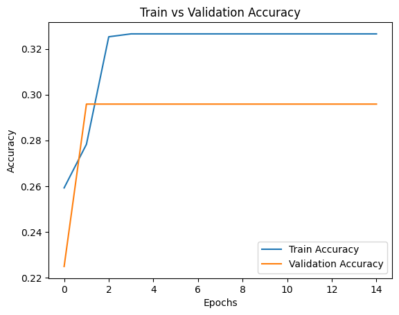

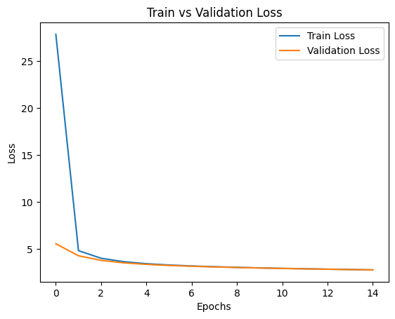

```python
# Plot accuracy graph
plt.plot(history.history['accuracy'], label='Train Accuracy')
plt.plot(history.history['val_accuracy'], label='Validation Accuracy')
plt.xlabel('Epochs')
plt.ylabel('Accuracy')
plt.legend()
plt.title('Train vs Validation Accuracy')
plt.show()

# Plot loss graph
plt.plot(history.history['loss'], label='Train Loss')
plt.plot(history.history['val_loss'], label='Validation Loss')
plt.xlabel('Epochs')
plt.ylabel('Loss')
plt.legend()
plt.title('Train vs Validation Loss')
plt.show()
```

#### Train vs Validation Loss

- Trend: Loss of both training set and validation set are gradually decreasing.
- Loss distance: The gap is quite close to each other, which shows the model is not overfitting.
- Loss reduction: There are no large fluctuations; providing that training is stable

#### Make and show predictions

```
1/1 ━━━━━━━━━━━━━━━━━━━━ 3s 3s/step
```

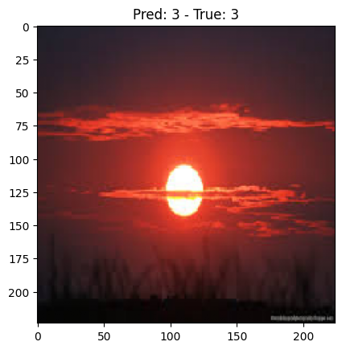

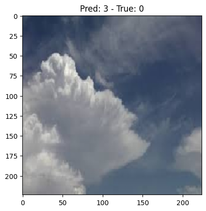

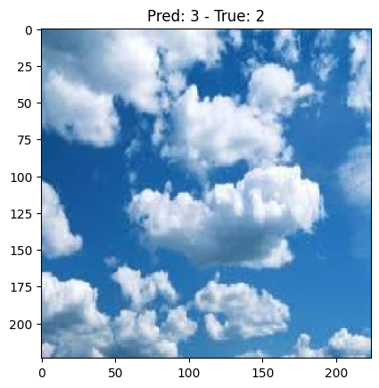

[figure not shown]

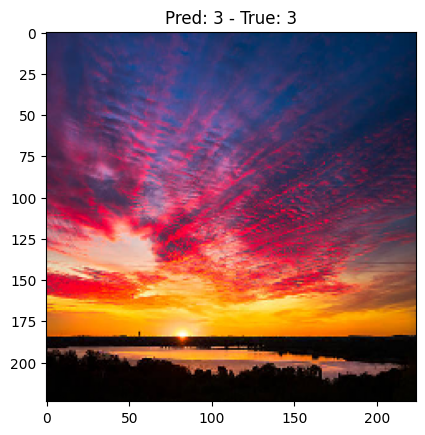

```python
# Chose random 5 samples from validation
num_samples = 5
indices = np.random.choice(len(X_val), num_samples, replace=False)
sample_images = X_val[indices]
sample_labels = y_val[indices]

# Prediction
predictions = model.predict(sample_images)

# Plot the result, 4 classes: ['Cloudy', 'Rain', 'Shine', 'Sunrise']
for i in range(num_samples):
    plt.imshow(sample_images[i])
    plt.title(f'Pred: {np.argmax(predictions[i])} - True: {np.argmax(sample_labels[i])}')
    plt.show()
```

### make confusion matrix

```
11/11 ━━━━━━━━━━━━━━━━━━━━ 2s 126ms/step
```

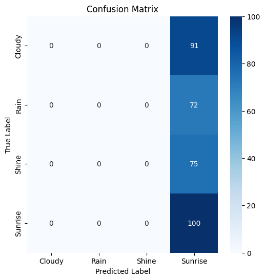

```python
# Predict the probabilities of classes on the validation set
y_pred_probs = model.predict(X_val)

# Convert to a label by taking the value with the highest probability
y_pred = np.argmax(y_pred_probs, axis=1)

# Convert it back to label format when y_val is in one-hot encoding
y_true = np.argmax(y_val, axis=1)

# Definition of class labels
class_labels = ['Cloudy', 'Rain', 'Shine', 'Sunrise']

# Create confusion matrix
cm = confusion_matrix(y_true, y_pred)

# Plot confusion matrix
plt.figure(figsize=(6,6))
sns.heatmap(cm, annot=True, fmt="d", cmap="Blues", xticklabels=class_labels, yticklabels=class_labels)
plt.xlabel("Predicted Label")
plt.ylabel("True Label")
plt.title("Confusion Matrix")
plt.show()
```

| True Label / Predicted label | Cloudy | Rain | Shine | Sunrise |
| --- | --- | --- | --- | --- |
| Cloudy | 0 | 0 | 0 | 91 |
| Rain | 0 | 0 | 0 | 72 |
| Shine | 0 | 0 | 0 | 75 |
| Sunrise | 0 | 0 | 0 | 100 |

#### Main diagonal (0, 0, 0, 100) → True Positives

- 0 Cloudy photos were correctly predicted.
- 0 Rain photos were correctly.
- 0 Shine photos were correctly predicted.
- 100 Sunrise photos were correctly predicted (perfect accuracy for Sunrise class).
- This means that only the "Sunrise" class is recognized correctly, all other classes are confused.

#### Values out off the main diagonal → False Positives

- 91 Cloudy photos were mistaken for Sunrise.
- 72 photos of Rain were mistaken for Sunrise.
- 75 photos of Shine were mistaken for Sunrise.
- This shows that the model is tending to predict all images as "Sunrise".

#### Evaluate the model

- Poor classification performance overall.
- Cloudy, Rain, Shine have 0% accuracy.
- Extreme class bias toward Sunrise.

### Load again the cnn but this time set the parameters to NOT TRAINABLE

```python
# Set trainable (True, False)
isTrainable = False

baseModel = VGG19(input_shape=target_size, weights='imagenet', include_top=False) # Input model use VGG19 use imagenet weight

# Freeze all layers of VGG19
for layer_ctn, layer in enumerate(baseModel.layers[:]):
    layer.trainable = isTrainable

# Flatten layer to convert from 4D tensor -> 1D vector
x = Flatten()(baseModel.output)

# Fully Connected Layers (Dense + Dropout)
x = Dense(512, activation='relu', kernel_regularizer=l1_l2(l1=0, l2=0.01))(x) # Add a Dense layer with 512 units
x = Dropout(0.1)(x) # Dropout layer with 0.1 unit
x = Dense(256, activation='relu', kernel_regularizer=l1_l2(l1=0, l2=0.01))(x) # Add a Dense layer with 256 units
x = Dropout(0.1)(x) # Dropout layer with 0.1 unit

# Output layer with 4 classes for the final classifier
x = Dense(4, activation='softmax')(x)  # 4 classes: ['Cloudy', 'Rain', 'Shine', 'Sunrise']

# Combine base_model and Fully Connected layers into a final model
model = Model(inputs=baseModel.input, outputs=x)

model.summary() # Print mode summary
```

```
Model: "functional_1"
```

```
┏━━━━━━━━━━━━━━━━━━━━━━━━━━━━━━━━━┳━━━━━━━━━━━━━━━━━━━━━━━━┳━━━━━━━━━━━━━━━┓
┃ Layer (type)                    ┃ Output Shape           ┃       Param # ┃
┡━━━━━━━━━━━━━━━━━━━━━━━━━━━━━━━━━╇━━━━━━━━━━━━━━━━━━━━━━━━╇━━━━━━━━━━━━━━━┩
│ input_layer_1 (InputLayer)      │ (None, 224, 224, 3)    │             0 │
├─────────────────────────────────┼────────────────────────┼───────────────┤
│ block1_conv1 (Conv2D)           │ (None, 224, 224, 64)   │         1,792 │
├─────────────────────────────────┼────────────────────────┼───────────────┤
│ block1_conv2 (Conv2D)           │ (None, 224, 224, 64)   │        36,928 │
├─────────────────────────────────┼────────────────────────┼───────────────┤
│ block1_pool (MaxPooling2D)      │ (None, 112, 112, 64)   │             0 │
├─────────────────────────────────┼────────────────────────┼───────────────┤
│ block2_conv1 (Conv2D)           │ (None, 112, 112, 128)  │        73,856 │
├─────────────────────────────────┼────────────────────────┼───────────────┤
│ block2_conv2 (Conv2D)           │ (None, 112, 112, 128)  │       147,584 │
├─────────────────────────────────┼────────────────────────┼───────────────┤
│ block2_pool (MaxPooling2D)      │ (None, 56, 56, 128)    │             0 │
├─────────────────────────────────┼────────────────────────┼───────────────┤
│ block3_conv1 (Conv2D)           │ (None, 56, 56, 256)    │       295,168 │
├─────────────────────────────────┼────────────────────────┼───────────────┤
│ block3_conv2 (Conv2D)           │ (None, 56, 56, 256)    │       590,080 │
├─────────────────────────────────┼────────────────────────┼───────────────┤
│ block3_conv3 (Conv2D)           │ (None, 56, 56, 256)    │       590,080 │
├─────────────────────────────────┼────────────────────────┼───────────────┤
│ block3_conv4 (Conv2D)           │ (None, 56, 56, 256)    │       590,080 │
├─────────────────────────────────┼────────────────────────┼───────────────┤
│ block3_pool (MaxPooling2D)      │ (None, 28, 28, 256)    │             0 │
├─────────────────────────────────┼────────────────────────┼───────────────┤
│ block4_conv1 (Conv2D)           │ (None, 28, 28, 512)    │     1,180,160 │
├─────────────────────────────────┼────────────────────────┼───────────────┤
│ block4_conv2 (Conv2D)           │ (None, 28, 28, 512)    │     2,359,808 │
├─────────────────────────────────┼────────────────────────┼───────────────┤
│ block4_conv3 (Conv2D)           │ (None, 28, 28, 512)    │     2,359,808 │
├─────────────────────────────────┼────────────────────────┼───────────────┤
│ block4_conv4 (Conv2D)           │ (None, 28, 28, 512)    │     2,359,808 │
├─────────────────────────────────┼────────────────────────┼───────────────┤
│ block4_pool (MaxPooling2D)      │ (None, 14, 14, 512)    │             0 │
├─────────────────────────────────┼────────────────────────┼───────────────┤
│ block5_conv1 (Conv2D)           │ (None, 14, 14, 512)    │     2,359,808 │
├─────────────────────────────────┼────────────────────────┼───────────────┤
│ block5_conv2 (Conv2D)           │ (None, 14, 14, 512)    │     2,359,808 │
├─────────────────────────────────┼────────────────────────┼───────────────┤
│ block5_conv3 (Conv2D)           │ (None, 14, 14, 512)    │     2,359,808 │
├─────────────────────────────────┼────────────────────────┼───────────────┤
│ block5_conv4 (Conv2D)           │ (None, 14, 14, 512)    │     2,359,808 │
├─────────────────────────────────┼────────────────────────┼───────────────┤
│ block5_pool (MaxPooling2D)      │ (None, 7, 7, 512)      │             0 │
├─────────────────────────────────┼────────────────────────┼───────────────┤
│ flatten_1 (Flatten)             │ (None, 25088)          │             0 │
├─────────────────────────────────┼────────────────────────┼───────────────┤
│ dense_3 (Dense)                 │ (None, 512)            │    12,845,568 │
├─────────────────────────────────┼────────────────────────┼───────────────┤
│ dropout_2 (Dropout)             │ (None, 512)            │             0 │
├─────────────────────────────────┼────────────────────────┼───────────────┤
│ dense_4 (Dense)                 │ (None, 256)            │       131,328 │
├─────────────────────────────────┼────────────────────────┼───────────────┤
│ dropout_3 (Dropout)             │ (None, 256)            │             0 │
├─────────────────────────────────┼────────────────────────┼───────────────┤
│ dense_5 (Dense)                 │ (None, 4)              │         1,028 │
└─────────────────────────────────┴────────────────────────┴───────────────┘
```

```
 Total params: 33,002,308 (125.89 MB)
```

```
 Trainable params: 12,977,924 (49.51 MB)
```

```
 Non-trainable params: 20,024,384 (76.39 MB)
```

### Fit the model with batch size 32 and 15 epochs (This is fsaster)

```python
# Compile model with Adam
model.compile(
    optimizer=Adam(learning_rate=0.001),
    loss='categorical_crossentropy', # Use categorical_crossentrop for multi-class classification
    metrics=['accuracy']
)

# Train model with epochs = 15, batch_size = 32
history = model.fit(X_train, y_train,
                    epochs=15, batch_size=32,
                    validation_data=(X_val, y_val))
```

```
25/25 ━━━━━━━━━━━━━━━━━━━━ 13s 442ms/step - accuracy: 0.3825 - loss: 12.1266 - val_accuracy: 0.7219 - val_loss: 5.0827
25/25 ━━━━━━━━━━━━━━━━━━━━ 3s 132ms/step - accuracy: 0.8157 - loss: 4.2797 - val_accuracy: 0.7249 - val_loss: 3.2858
25/25 ━━━━━━━━━━━━━━━━━━━━ 3s 127ms/step - accuracy: 0.8272 - loss: 2.8125 - val_accuracy: 0.8905 - val_loss: 2.1537
25/25 ━━━━━━━━━━━━━━━━━━━━ 3s 124ms/step - accuracy: 0.9541 - loss: 1.9234 - val_accuracy: 0.9083 - val_loss: 1.7115
25/25 ━━━━━━━━━━━━━━━━━━━━ 3s 125ms/step - accuracy: 0.9436 - loss: 1.5715 - val_accuracy: 0.8876 - val_loss: 1.5914
25/25 ━━━━━━━━━━━━━━━━━━━━ 3s 124ms/step - accuracy: 0.8951 - loss: 1.4987 - val_accuracy: 0.9053 - val_loss: 1.4403
25/25 ━━━━━━━━━━━━━━━━━━━━ 3s 127ms/step - accuracy: 0.9292 - loss: 1.3445 - val_accuracy: 0.8846 - val_loss: 1.3637
25/25 ━━━━━━━━━━━━━━━━━━━━ 3s 128ms/step - accuracy: 0.9547 - loss: 1.1552 - val_accuracy: 0.8905 - val_loss: 1.2334
25/25 ━━━━━━━━━━━━━━━━━━━━ 3s 129ms/step - accuracy: 0.9816 - loss: 0.9886 - val_accuracy: 0.9053 - val_loss: 1.0947
25/25 ━━━━━━━━━━━━━━━━━━━━ 3s 126ms/step - accuracy: 0.9612 - loss: 0.9302 - val_accuracy: 0.8254 - val_loss: 1.2628
25/25 ━━━━━━━━━━━━━━━━━━━━ 3s 131ms/step - accuracy: 0.9159 - loss: 1.0628 - val_accuracy: 0.8462 - val_loss: 1.2218
25/25 ━━━━━━━━━━━━━━━━━━━━ 3s 129ms/step - accuracy: 0.9358 - loss: 1.0028 - val_accuracy: 0.8521 - val_loss: 1.2416
25/25 ━━━━━━━━━━━━━━━━━━━━ 3s 128ms/step - accuracy: 0.9331 - loss: 0.9527 - val_accuracy: 0.8787 - val_loss: 1.0426
25/25 ━━━━━━━━━━━━━━━━━━━━ 3s 126ms/step - accuracy: 0.9699 - loss: 0.8234 - val_accuracy: 0.8698 - val_loss: 0.9953
25/25 ━━━━━━━━━━━━━━━━━━━━ 3s 128ms/step - accuracy: 0.9272 - loss: 0.8641 - val_accuracy: 0.7781 - val_loss: 1.3017
```

# Evaluate the model

```python
test_loss, test_acc = model.evaluate(X_val, y_val)
print(f"Accuracy: {test_acc*100:.2f}%")
```

```
11/11 ━━━━━━━━━━━━━━━━━━━━ 1s 84ms/step - accuracy: 0.7701 - loss: 1.2972
Accuracy: 77.81%
```

#### Draw a chart of the training process to check overfitting/underfitting

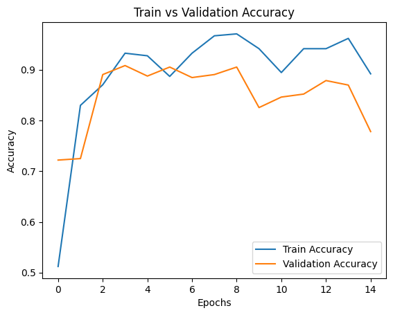

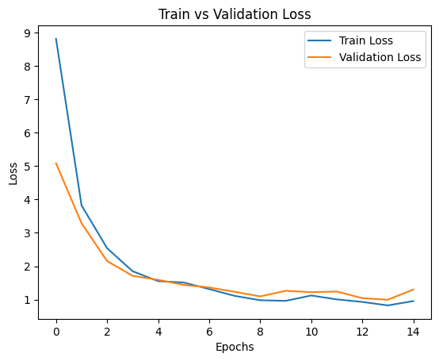

```python
# Plot accuracy graph
plt.plot(history.history['accuracy'], label='Train Accuracy')
plt.plot(history.history['val_accuracy'], label='Validation Accuracy')
plt.xlabel('Epochs')
plt.ylabel('Accuracy')
plt.legend()
plt.title('Train vs Validation Accuracy')
plt.show()

# Plot loss graph
plt.plot(history.history['loss'], label='Train Loss')
plt.plot(history.history['val_loss'], label='Validation Loss')
plt.xlabel('Epochs')
plt.ylabel('Loss')
plt.legend()
plt.title('Train vs Validation Loss')
plt.show()
```

#### Train vs Validation Loss

- Trend: Loss of both training set and validation set are gradually decreasing.
- Loss distance: The gap is quite close to each other, which shows the model is not overfitting.
- Loss reduction: There are no large fluctuations; providing that training is stable

### Make and show some predictions

```
1/1 ━━━━━━━━━━━━━━━━━━━━ 1s 567ms/step
```

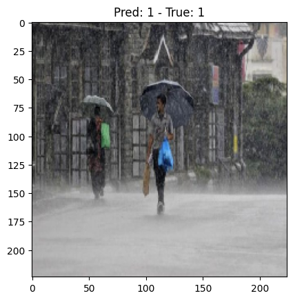

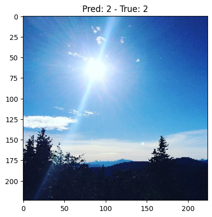

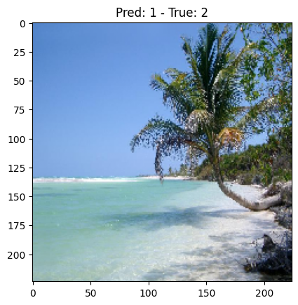

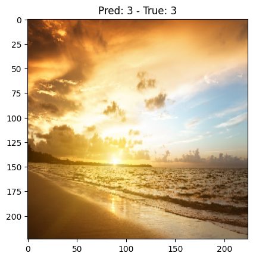

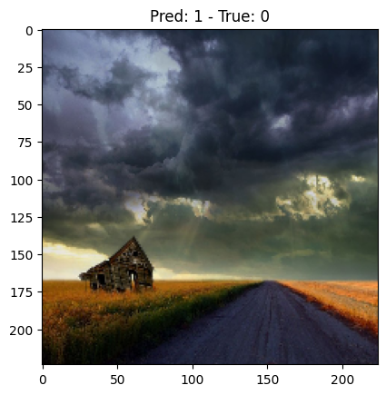

```python
# Chose random 5 samples from validation
num_samples = 5
indices = np.random.choice(len(X_val), num_samples, replace=False)
sample_images = X_val[indices]
sample_labels = y_val[indices]

# Prediction
predictions = model.predict(sample_images)

# Plot the result, 4 classes: ['Cloudy', 'Rain', 'Shine', 'Sunrise']
for i in range(num_samples):
    plt.imshow(sample_images[i])
    plt.title(f'Pred: {np.argmax(predictions[i])} - True: {np.argmax(sample_labels[i])}')
    plt.show()
```

### make confusion matrix

```
11/11 ━━━━━━━━━━━━━━━━━━━━ 2s 120ms/step
```

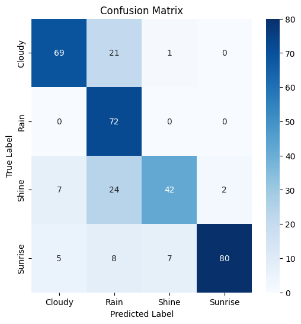

```python
# Predict the probabilities of classes on the validation set
y_pred_probs = model.predict(X_val)

# Convert to a label by taking the value with the highest probability
y_pred = np.argmax(y_pred_probs, axis=1)

# Convert it back to label format when y_val is in one-hot encoding
y_true = np.argmax(y_val, axis=1)

# Definition of class labels
class_labels = ['Cloudy', 'Rain', 'Shine', 'Sunrise']

# Create confusion matrix
cm = confusion_matrix(y_true, y_pred)

# Plot confusion matrix
plt.figure(figsize=(6,6))
sns.heatmap(cm, annot=True, fmt="d", cmap="Blues", xticklabels=class_labels, yticklabels=class_labels)
plt.xlabel("Predicted Label")
plt.ylabel("True Label")
plt.title("Confusion Matrix")
plt.show()
```

| True Label / Predicted label | Cloudy | Rain | Shine | Sunrise |
| --- | --- | --- | --- | --- |
| Cloudy | 69 | 21 | 1 | 0 |
| Rain | 0 | 72 | 0 | 0 |
| Shine | 7 | 24 | 42 | 2 |
| Sunrise | 5 | 8 | 7 | 80 |

- 69 Cloudy photos were correctly predicted.
- 72 Rain photos were correctly.
- 42 Shine photos were correctly predicted.
- 80 Sunrise photos were correctly predicted.

#### Values out off the main diagonal → False Positives

- 21 Cloudy photos were mistaken for Rain.
- 7 photos of Shine were mistaken for Cloudy.
- 24 photos of Shine were mistaken for Rain.
- 2 photos of Shine were mistaken for Sunrise.
- 5 photos of Sunrise were mistaken for Cloudy.
- 8 photos of Sunrise were mistaken for Rain.
- 7 photos of Sunrise were mistaken for Shine.

#### Compare two models

| Method | Train Accuracy | Validation Accuracy | Test Accuracy | Evaluation |
| --- | --- | --- | --- | --- |
| (trainable = True) | 32% | 30% | 29.59% | Poor classification performance overall. |
| (trainable = False) | 90% | 80% | 77.81% | Good performance in overall, a small sign of overfitting but it is not significant |

#### Trainable = False (90% train - 80% validation)

- Learn well because It takes advantage of ImageNet features.

#### Conclusion

| Train Method | When to be used? |
| --- | --- |
| Trainable = True | When there is a large data set, it helps the model learn more optimally. Needs a more powerful GPU to train. |
| Trainable = False | When the dataset is small, avoid overfitting but may suffer from underfitting. Train faster. |